# BarplotsINEMortalitySex

2022-12-27

## Import data

*Data Source*:

```r
data<-read.csv("Provincias_datos.csv", sep = ",")
# Glimpse of the dataset
head(data)
```

```
##   Lugar   Mes    Sexo  Total
## 1 Total Total   Total 166773
## 2 Total Total Hombres  80740
## 3 Total Total Mujeres  86033
## 4 Total Enero   Total  13866
## 5 Total Enero Hombres   6639
## 6 Total Enero Mujeres   7227
```

# Crude Mortality Rate Visualizations

## 1. Month Deaths Bar Chart

## Data preprocessing

Taking total cases, and month data, dropping missing values and translating month labels

```r
datatotalmonth = data[which(data["Lugar"]=="Total"),]
datatotalmonth = datatotalmonth[which(data["Mes"]!="Total"),]
datatotalmonth = datatotalmonth[which(data["Sexo"]=="Total"),]
datatotalmonth = datatotalmonth %>% drop_na()
```

Subsetting and reformatting final dataframe

```r
datatotalmonth = datatotalmonth[,c("Mes", "Total")]

levels_order <-  c("January", "February", "March", "April", "May", "June", "July", "August", "September", "October", "November", "December")
datatotalmonth[,"Mes"] <- levels_order

# Necessary to reformat for ggplot
plotmonth = melt(datatotalmonth)
colnames(plotmonth) = c("Month", "Stratification", "Deaths")
```

## Plotting

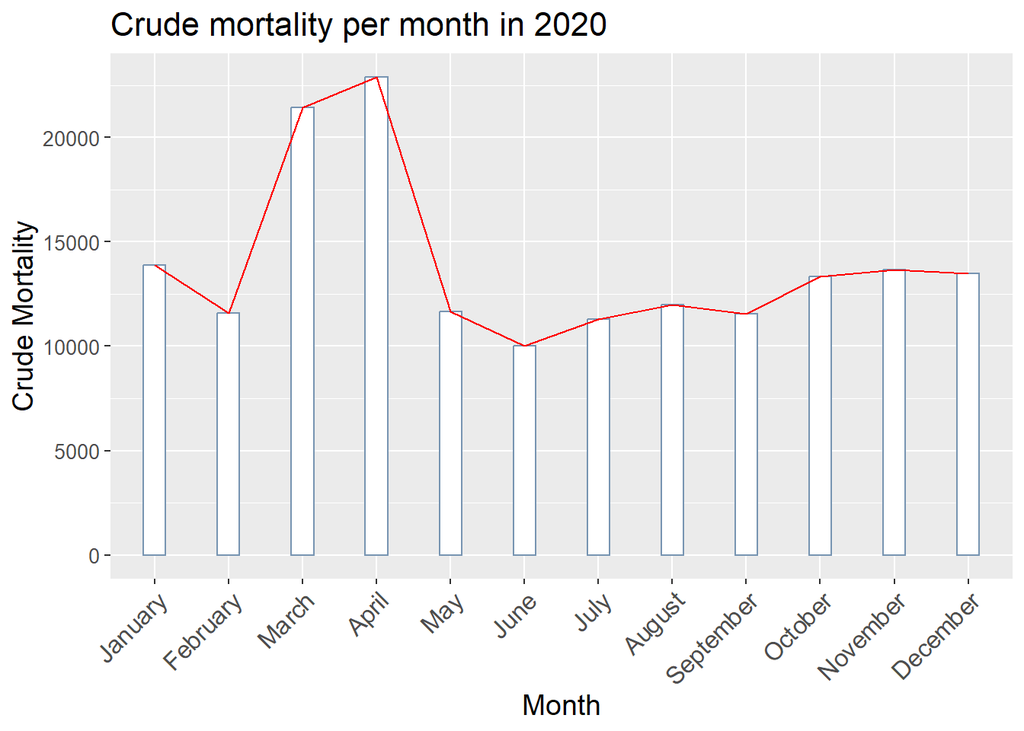

## 2. Month Sex Deaths Bar Chart

## Data preprocessing

Taking total cases, sex data and month data, dropping missing values and translating month and sex labels

```r
datatotalmonthsex = data[which(data["Lugar"]=="Total"),]
datatotalmonthsex = datatotalmonthsex[which(data["Mes"]!="Total"),]
datatotalmonthsex = datatotalmonthsex %>% drop_na()
```

Subsetting and reformatting final dataframe

```r
datatotalmonthsex = datatotalmonthsex[,c("Mes", "Sexo","Total")]

# This time for translation of labels it is necessary to replicate the sex for each of the three sex labels per  instance
datatotalmonthsex["Sexo"] <- rep_len(c("Total", "Male", "Female"),3)

# This time for translation of labels it is necessary to replicate the months for each of the three sex labels per instance
levels_order <-  c(rep_len("January",3), rep_len("February",3), rep_len("March",3), rep_len("April",3),
                   rep_len("May",3), rep_len("June",3), rep_len("July",3), rep_len("August",3),
                   rep_len("September",3), rep_len("October",3), rep_len("November",3), rep_len("December",3))
datatotalmonthsex[,"Mes"] <- levels_order

# Necessary to reformat for ggplot
plotmonthsex = melt(datatotalmonthsex)
colnames(plotmonthsex) = c("Month", "Sex", "Stratification", "Deaths")
df=data.frame(plotmonthsex)
```

## Plotting

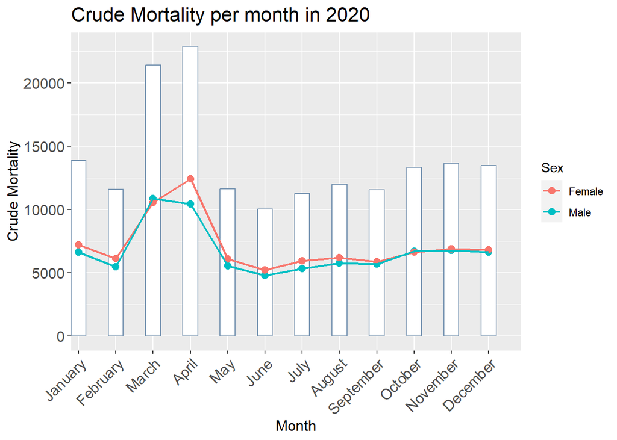

## 3. Distribution of Deaths per month boxplot

## Data preprocessing

Taking total cases, sex data and month data, dropping missing values and translating month and sex labels

```r
datatotal = data[which(data["Lugar"]!="Total"),]
datatotal = datatotal[which(data["Mes"]!="Total"),]
datatotal = datatotal[which(data["Sexo"]=="Total"),]
datatotal = datatotal %>% drop_na()
```

Subsetting and reformatting final dataframe

```r
datatotal = datatotal[,c("Lugar", "Mes", "Total")]

# Gets number of provinces in the dataset for translation of month values through repetition
numprov <- length(unique(datatotal["Lugar"])[,1])

# This time for translation of labels it is necessary to replicate the months for each of the three sex labels per instance
levels_order <-  rep_len(c("January", "February", "March", "April", "May", "June", "July", "August", "September", "October", "November", "December"), numprov)
datatotal[,"Mes"] <- levels_order

# Necessary to reformat for ggplot
plottotalbp = melt(datatotal)
colnames(plottotalbp) = c("Province", "Month", "Stratification","Deaths")
df=data.frame(plottotalbp)
```

## Plotting

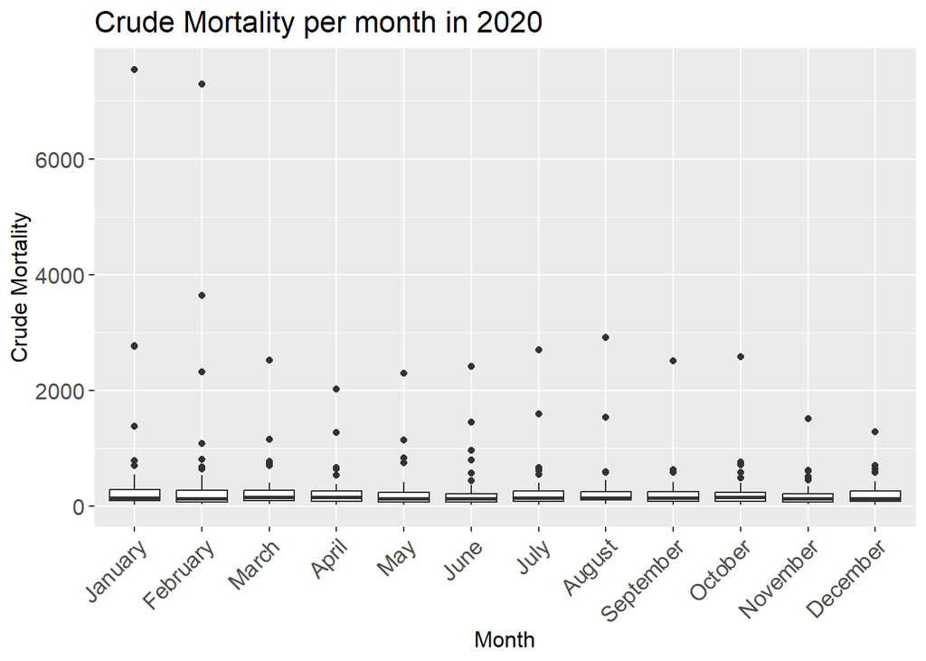

## 4. Plotting by province with ordered medians

```r
 # Order boxes by median
group_ordered <- with(df,
                      reorder(Province,
                              Deaths,
                              median))

# Create data with reordered group levels
datatotal_ordered <- df
datatotal_ordered$group <- factor(datatotal_ordered$Province,
                             levels = levels(group_ordered))
```

## Plotting

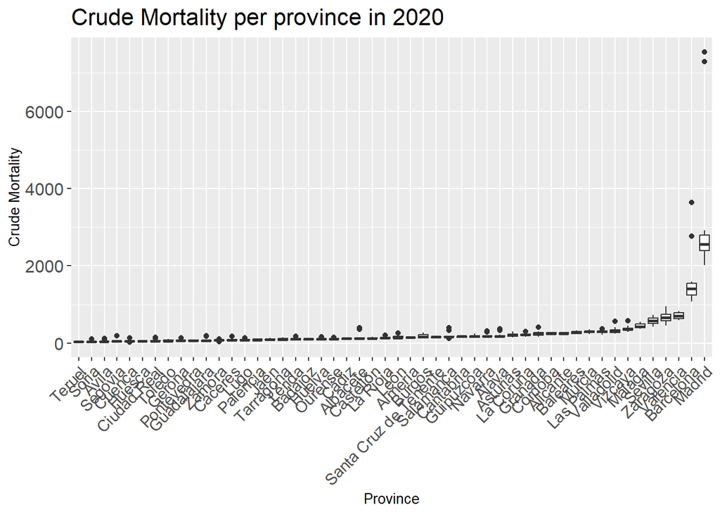

## 5. Grouping by Autonomic Community

```r
map_ccaa_prov <- read.csv("data/ccaa_provincia.csv")
colnames(map_ccaa_prov) <- c("CCAA","Lugar")
dataccaa <- merge(data,map_ccaa_prov,by="Lugar")
```

## Data preprocessing

Taking total cases, sex data and month data, dropping missing values and translating month and sex labels

```r
dataccaa = dataccaa[which(data["Lugar"]!="Total"),]
dataccaa = dataccaa[which(data["Mes"]!="Total"),]
dataccaa = dataccaa[which(data["Sexo"]=="Total"),]
dataccaa = dataccaa %>% drop_na()
```

Subsetting and reformatting final dataframe

```r
dataccaa = dataccaa[,c("CCAA", "Mes", "Total")]

# Gets number of provinces in the dataset for translation of month values through repetition
numprov <- length(unique(datatotal["Lugar"])[,1])

# This time for translation of labels it is necessary to replicate the months for each of the three sex labels per instance
levels_order <-  rep_len(c("January", "February", "March", "April", "May", "June", "July", "August", "September", "October", "November", "December"), numprov)
datatotal[,"Mes"] <- levels_order

# Necessary to reformat for ggplot
plotccaabp = melt(dataccaa)
colnames(plotccaabp) = c("CCAA", "Month","Stratification","Deaths")
df=data.frame(plotccaabp)
```

```r
 # Order boxes by median
group_ordered <- with(df,
                      reorder(CCAA,
                              Deaths,
                              median))

# Create data with reordered group levels
datatotal_ordered <- df
datatotal_ordered$group <- factor(datatotal_ordered$CCAA,
                             levels = levels(group_ordered))
```

## Plotting

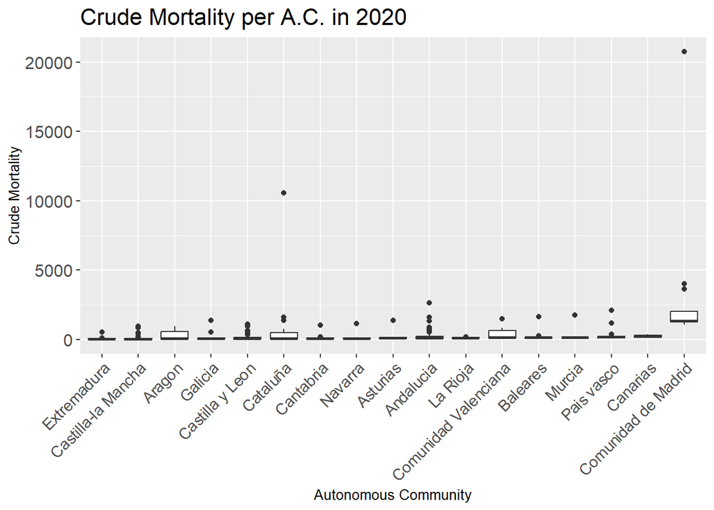

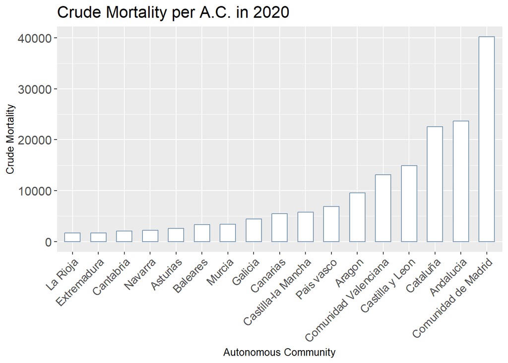

# Death Rate Per 100,000 inhabitants visualization

In reference to the population of provinces in the end of 2019

```r
death_census <- read.csv("Death_Census_Perc.csv")

# Merging on province to get populations of men, women and total populations in 2019
datapob19 <- death_census[, c('Lugar','men','women','pob19')]
dataDR <- merge(data,datapob19,by="Lugar")
```

Calculating Death Rate per month and province

```r
# Calculating Death Rate DR per population group
dataDR$DR <- NULL

# Creating variables indexing rows by stratification population (Total,men,women)
BOOLTOTAL <- which(dataDR['Sexo']=='Total')
dataDR[BOOLTOTAL,'DR'] <- ( dataDR[BOOLTOTAL,'Total'] / dataDR[BOOLTOTAL,'pob19'] ) * 100000

BOOLMEN <- which(dataDR['Sexo']=='Hombres')
dataDR[BOOLMEN,'DR'] <- ( dataDR[BOOLMEN,'Total'] / dataDR[BOOLMEN, 'men'] ) * 100000

BOOLWOMEN <- which(dataDR['Sexo']=='Mujeres')
dataDR[BOOLWOMEN,'DR'] <- ( dataDR[BOOLWOMEN,'Total'] / dataDR[BOOLWOMEN,'women']) * 100000
```

## 1. Month Death Rate Bar chart

## Data preprocessing

```r
datatotalmonth = dataDR[which(data["Lugar"]=="Total"),]
datatotalmonth = datatotalmonth[which(data["Mes"]!="Total"),]
datatotalmonth = datatotalmonth[which(data["Sexo"]=="Total"),]
datatotalmonth = datatotalmonth %>% drop_na()
datatotalmonth = datatotalmonth[,c("Mes", "DR")]

levels_order <-  c("January", "February", "March", "April", "May", "June", "July", "August", "September", "October", "November", "December")
datatotalmonth[,"Mes"] <- levels_order

# Necessary to reformat for ggplot
plotmonth = melt(datatotalmonth)
colnames(plotmonth) = c("Month", "Stratification", "DeathRate")
```

## Plotting

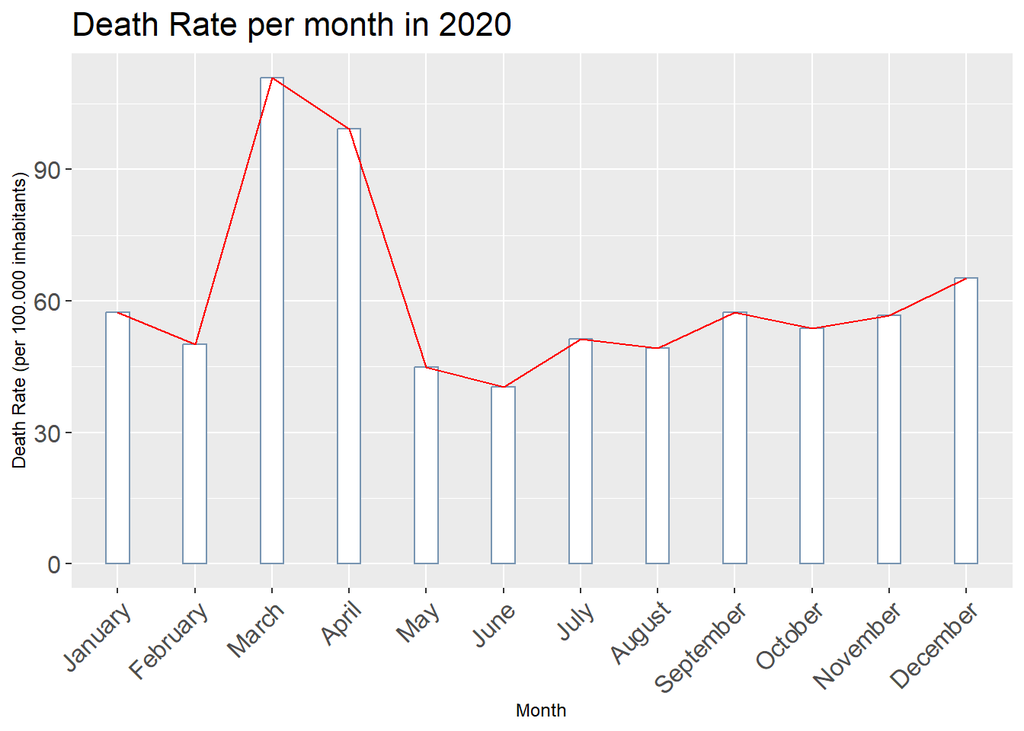

## 2. Month Sex Deaths Bar Chart

## Data preprocessing

Taking total cases, sex data and month data, dropping missing values and translating month and sex labels

```r
datatotalmonthsex = dataDR[which(data["Lugar"]=="Total"),]
datatotalmonthsex = datatotalmonthsex[which(data["Mes"]!="Total"),]
datatotalmonthsex = datatotalmonthsex %>% drop_na()
```

Subsetting and reformatting final dataframe

```r
datatotalmonthsex = datatotalmonthsex[,c("Mes", "Sexo","DR")]

# This time for translation of labels it is necessary to replicate the sex for each of the three sex labels per  instance
datatotalmonthsex["Sexo"] <- rep_len(c("Total", "Male", "Female"),3)

# This time for translation of labels it is necessary to replicate the months for each of the three sex labels per instance
levels_order <-  c(rep_len("January",3), rep_len("February",3), rep_len("March",3), rep_len("April",3),
                   rep_len("May",3), rep_len("June",3), rep_len("July",3), rep_len("August",3),
                   rep_len("September",3), rep_len("October",3), rep_len("November",3), rep_len("December",3))
datatotalmonthsex[,"Mes"] <- levels_order

# Necessary to reformat for ggplot
plotmonthsex = melt(datatotalmonthsex)
colnames(plotmonthsex) = c("Month", "Sex", "Stratification", "DeathRate")
df=data.frame(plotmonthsex)
```

## Plotting

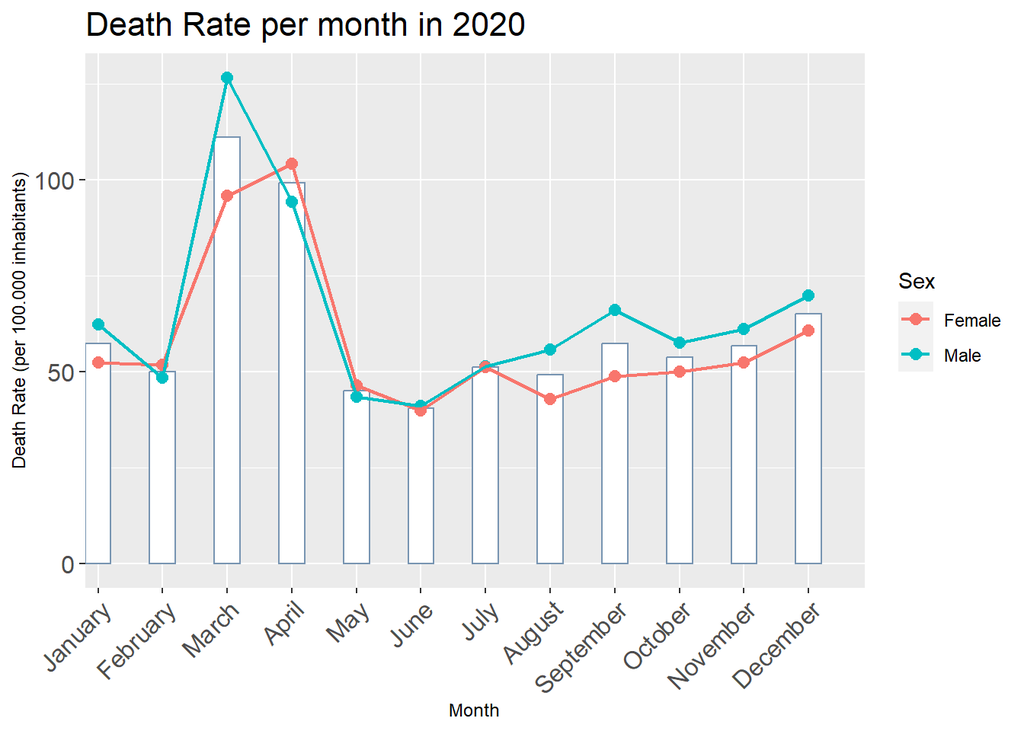

## 3. Distribution of Deaths per month boxplot

## Data preprocessing

Taking total cases, sex data and month data, dropping missing values and translating month and sex labels

```r
datatotal = dataDR[which(data["Lugar"]!="Total"),]
datatotal = datatotal[which(data["Mes"]!="Total"),]
datatotal = datatotal[which(data["Sexo"]=="Total"),]
datatotal = datatotal %>% drop_na()
```

Subsetting and reformatting final dataframe

```r
datatotal = datatotal[,c("Lugar", "Mes", "DR")]

# Gets number of provinces in the dataset for translation of month values through repetition
numprov <- length(unique(datatotal["Lugar"])[,1])

# This time for translation of labels it is necessary to replicate the months for each of the three sex labels per instance
levels_order <-  rep_len(c("January", "February", "March", "April", "May", "June", "July", "August", "September", "October", "November", "December"), numprov)
datatotal[,"Mes"] <- levels_order

# Necessary to reformat for ggplot
plottotalbp = melt(datatotal)
colnames(plottotalbp) = c("Province", "Month", "Stratification","DeathRate")
df=data.frame(plottotalbp)
```

## Plotting

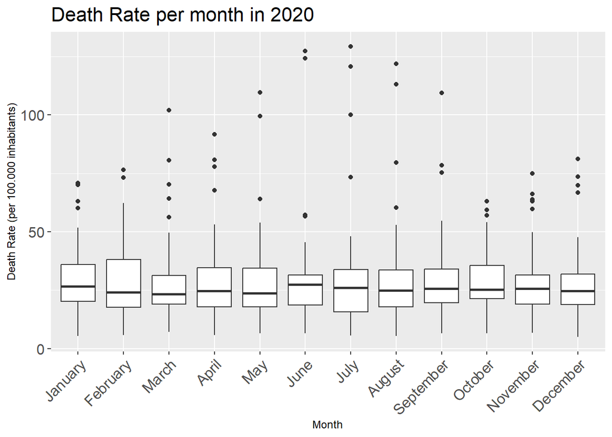

## 4. Plotting by province with ordered medians

```r
 # Order boxes by median
group_ordered <- with(df,
                      reorder(Province,
                              DeathRate,
                              median))

# Create data with reordered group levels
datatotal_ordered <- df
datatotal_ordered$group <- factor(datatotal_ordered$Province,
                             levels = levels(group_ordered))
```

## Plotting

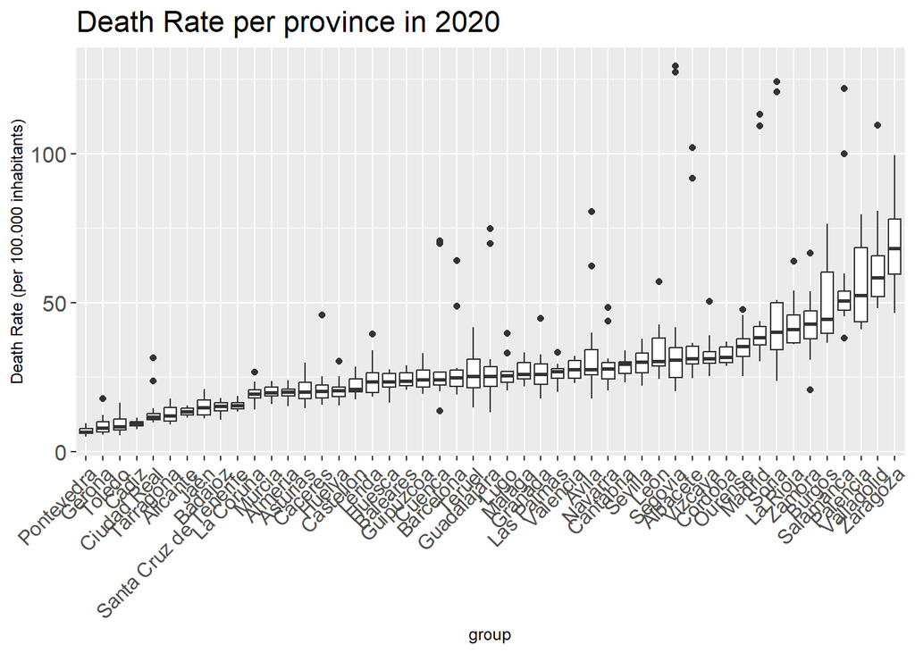

## 5. Grouping by Autonomic Community

```r
map_ccaa_prov <- read.csv("data/ccaa_provincia.csv")
colnames(map_ccaa_prov) <- c("CCAA","Lugar")
dataccaa <- merge(dataDR,map_ccaa_prov,by="Lugar")
```

## Data preprocessing

Taking total cases, sex data and month data, dropping missing values and translating month and sex labels

```r
dataccaa = dataccaa[which(dataccaa["Lugar"]!="Total"),]
dataccaa = dataccaa[which(dataccaa["Mes"]!="Total"),]
dataccaa = dataccaa[which(dataccaa["Sexo"]=="Total"),]
dataccaa = dataccaa %>% drop_na()
```

Subsetting and reformatting final dataframe

```r
dataccaa = dataccaa[,c("CCAA", "Mes", "DR")]

# Gets number of provinces in the dataset for translation of month values through repetition
numprov <- length(unique(datatotal["Lugar"])[,1])

# This time for translation of labels it is necessary to replicate the months for each of the three sex labels per instance
levels_order <-  rep_len(c("January", "February", "March", "April", "May", "June", "July", "August", "September", "October", "November", "December"), numprov)
datatotal[,"Mes"] <- levels_order

# Necessary to reformat for ggplot
plotccaabp = melt(dataccaa)
colnames(plotccaabp) = c("CCAA", "Month","Stratification","DeathRate")
df=data.frame(plotccaabp)
```

```r
 # Order boxes by median
group_ordered <- with(df,
                      reorder(CCAA,
                              DeathRate,
                              median))

# Create data with reordered group levels
datatotal_ordered <- df
datatotal_ordered$group <- factor(datatotal_ordered$CCAA,
                             levels = levels(group_ordered))
```

## Plotting

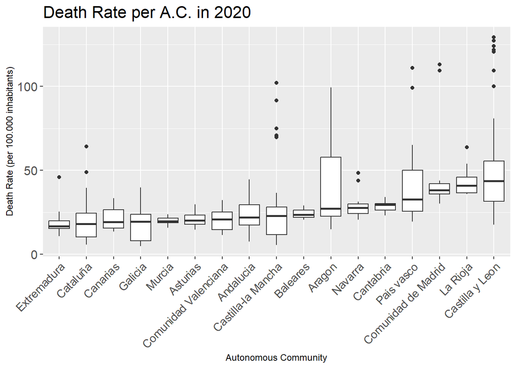

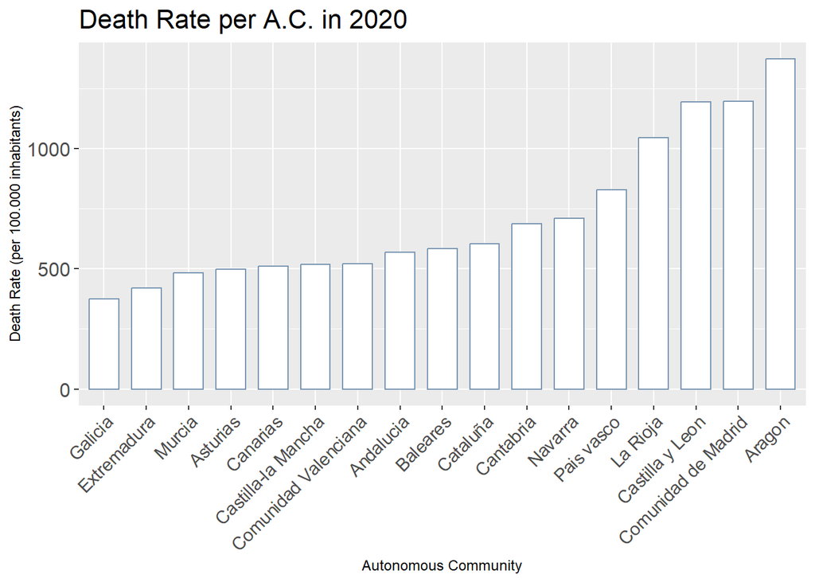

```r
datatotal <- data[which(data["Sexo"]=="Total"),]
dataccaa <- merge(datatotal,map_ccaa_prov,by="Lugar")

# Group by CCAA + sum deaths
dataaccumulativeccaa = dataccaa %>% group_by(CCAA) %>%
  summarise(sum.Total = sum(Total))

# Group by CCAA + sum pop19
datapobccaa <- merge(map_ccaa_prov,datapob19,by="Lugar")
datapobccaa= datapobccaa %>% group_by(CCAA) %>%
  summarise(sum.pob19 = sum(pob19))

dataDR <- merge(datapobccaa,dataaccumulativeccaa,by="CCAA")
dataDR$DR <- ( dataDR$sum.Total / dataDR$sum.pob19 ) * 100000
dataDR <- dataDR[,c('CCAA','DR')]


# Necessary to reformat for ggplot
plotccaa_acc = melt(dataDR)
colnames(plotccaa_acc) = c("CCAA", "Strat:Agg_Funct","DeathRate")
df=data.frame(plotccaa_acc)


# save info to write to csv later
dataCCAADR<-dataDR
```

```r
# saved acc data groupby CCAA
CCAAdata <- merge(dataCCAADR, dataCCAAMort, by='CCAA')
write.csv(CCAAdata, "CCAA_DR_Mortality_Population.csv")
```